# Data Mining Final Project

Ines Ajimi and Julia Tache

# Automatic Flagging of Youtube Community Guideline Violations

```r
# Loading Libraries
library("caret")
library("tidyverse")
library("tidytext")
library("rvest")
library('xgboost')
# Setting Seed
set.seed(15)
```

## Outline

Our objective is to automatically flag comments which violate [Youtube’s community guidelines](https://www.youtube.com/about/policies/#community-guidelines). We focus on comments which contain:

- nudity or sexual content
- harmful or dangerous content
- hateful content (*“content that promotes or condones violence against individuals or groups based on race or ethnic origin, religion, disability, gender, age, nationality, veteran status, caste, sexual orientation, or gender identity, or content that incites hatred on the basis of these core characteristics”*)
- violent or graphic content
- harassment or cyberbullying
- threats
- spam
- child safety

Our aim is to create a model which flags abusive messages with high accuracy.

CONTENT WARNING: This project and the code directly contains harmful and offensive words with the hopes that online abuse can be better flagged.

## Data

We downloaded a dataset of YouTube comments from [Kaggle](https://www.kaggle.com/datasnaek/youtube). This dataset contains 100 web-scraped comments for every video in the top 200 U.S. trending over a number of days, as well as information about the video those comments were posted on.

```r
# Number of Rows of OG DataFrame to Include
n <- 35000

# Loading Comment Data
UScomments <- read_csv("UScomments.csv")
UScomments <- distinct(UScomments)

# Adding Columns
reg_dataset <- data.frame(comment = iconv(UScomments$comment_text[1:n], "latin1", "ASCII", "byte"),
                          video_id = UScomments$video_id[1:n],
                          likes = UScomments$likes[1:n],
                          replies = UScomments$replies[1:n],
                          stringsAsFactors = FALSE) #creates dataset we'll work with

rm(UScomments) #removes dataset, to save space in memory

# Loading Video Data
UScomments_context <- read_csv("UScomments13.09.csv") %>%
  filter(!is.na(tags)) %>% #only keeps rows with video information
  select(-thumbnail_link, -comments_displayed_here)
# Adding _Video Suffix to Column Names
names(UScomments_context)[names(UScomments_context) != "video_id"] <- paste("video", names(UScomments_context)[names(UScomments_context) != "video_id"], sep = "_")

# Add to Core Dataset
reg_dataset <- left_join(reg_dataset, UScomments_context)
head(reg_dataset)
```

```
##                                                                                               comment
## 1 Logan Paul it's yo big day <e2><80><bc><ef><b8><8f><e2><80><bc><ef><b8><8f><e2><80><bc><ef><b8><8f>
## 2             I've been following you from the start of your vine channel and have seen all 365 vlogs
## 3                                                                  Say hi to Kong and maverick for me
## 4                                                                                 MY FAN . attendance
## 5                                                                           trending <f0><9f><98><89>
## 6                                                                             #1 on trending AYYEEEEE
##      video_id likes replies
## 1 XpVt6Z1Gjjo     4       0
## 2 XpVt6Z1Gjjo     3       0
## 3 XpVt6Z1Gjjo     3       0
## 4 XpVt6Z1Gjjo     3       0
## 5 XpVt6Z1Gjjo     3       0
## 6 XpVt6Z1Gjjo     3       0
##                                                     video_title
```

[output cut: 27 more lines]

```r
# Clear Memory
rm(UScomments_context)
```

We manually added messages which we found to violate Youtube’s community guidelines below.

```r
# Initial Vector
y <- rep(0, nrow(reg_dataset))

# Marking Comments that violate Terms
flagged_comments <- read_lines("flagged_comments.txt") %>%
  str_split(',') %>%
  flatten_chr() %>%
  as.numeric()

flagged_comments <- flagged_comments[!is.na(flagged_comments)]

y[c(flagged_comments)] <- 1
```

Due to the limited nature of our data, we primarily use the content of the comments, as well as some video-related context, to train our models. We explain the creation and rationale behind the variables we use in the following section.

## Methodology

Like them, we divide our analysis into 2 steps: pre-processing messages, followed by the implementation of classification models.

Pre-processing is done both to generally adjust to the nature of our data, which is primarily made up of comments, and to its source, the Internet. Given the latter, we clean our dataset to adjust for the presence of emojis (coded in a `<..>` format, e.g., `<e2><80><bc><ef><b8><8f><e2><80><bc><ef><b8><8f><e2><80><bc><ef><b8><8f>`) and links. We detect and remove links using a regex from [StackOverflow](https://stackoverflow.com/questions/26496538/extract-urls-with-regex-into-a-new-data-frame-column) and emojis using a list of emojis found online.

After pre-processing our dataset, we measure

- the number of characters within the message (message length)
- the number of *letters* within the message
- the number of *capital letters* within the message
- the number of *punctuation marks*
- the percentage of thre three variables above
- the difference in message length before and after collapse all repetitions of characters over 3 (e.g. “looooooooool” to “lool”)
- the average word length
- the number of “bad” (offensive) words, found from a [list](https://www.cs.cmu.edu/~biglou/resources/bad-words.txt) online, for every bad word
- the percentage of bad words within the message
- the sentiment score, adjusted for the presence of said insults
- the number of unique words
- the sum of tdif

Our approach is primarily *content-based* approach, relying on textual features to identify abusive messages. However, this creates a number of problems.

For one thing, negative sentiment and the presence of “bad words” doesn’t necessarily indicate that the comment itself is offensive. First, some “bad words” really aren’t bad in themselves: they are descriptive words which tend to be used in abusive contexts. “Gay”, for instance, is included in the “bad word” list and is, indeed, often used in this sample of YouTube comments as an insult. The risk is that this will lead our model to flag innocuous messages as abusive. Similarly, sentiment analysis can be imprecise: “I FUCKING LOVE YOU B <3” is obviously positive, yet has a sentiment value of -1. Our model also lacks the nuance to recognize popular references and copy-pasta.

Context also matters when it comes to the topic of the video. A lot of people call the IPhone X ugly: e.g., “looks ugly”. The same comment, were it posted on a human’s video, would be a form of cyberbullying and therefore flagged.

Another problem is that we classify both spam and threats / slurs with the same model and that these two different types of violations share fairly different characteristics. Spam tends to be repetitive, link to outside websites, or repeatedly ask people to “please subscribe”. They may have a low number of distinct words within a message. Abusive comments typically include slurs. Because both types are classified as 1 and not label as “spam” or “abusive”, our model may have trouble distinguishing between the two and predicting values accordingly.

## Data Cleaning

### Pre-Processing

First, we need to ‘translate’ the emojis, which currently appear as a sequence of symbols and numbers. For this, we rely on a R User’s [emoji decoder](http://opiateforthemass.es/articles/emoticons-in-R/) which they were kind enough to share as [a `.csv` file](https://github.com/today-is-a-good-day/emojis/blob/master/emDict.csv).

Following their steps, we convert our messages in a way which properly displays emojis. They will subsequently be treated as words. Moreover, we combined the “decoder” and [an emoji sentiment dictionary](http://kt.ijs.si/data/Emoji_sentiment_ranking/index.html) so as to compute their emotional valence. This emoji sentiment dictionary ranges between -1 and 1, which might cause a problem given that we will later be using the `afinn` sentiment dictionary, which ranks words between -5 and 5, for their emotional valence.

There are two ways to think of this: first, emojis aren’t quite bound to the same rules regarding repetition as words: it is much easier (and common) to tack on a series of emojis (e.g., the heart emoji) than to write a similar word sequence (e.g., “I love love love this”). It can therefore be argued that lower sentiment ranking for emojis is appropriate, as they will otherwise inflate the sentiment more than is appropriate. On the other hand, this line of thinking might underestimate the impact of emojis and the way they affect a comment’s tone. We include later on both the emoji sentiment value as is and the value multiplied by 5.

```r
# Import Emoji Decoder
emoji_decoder <- read_csv2("https://github.com/today-is-a-good-day/emojis/raw/master/emDict.csv")
```

```
## Using ',' as decimal and '.' as grouping mark. Use read_delim() for more control.
```

```r
# Import Emoji Sentiment Dataset
## Reading in URL
emoji_sent_resp <- read_html("http://kt.ijs.si/data/Emoji_sentiment_ranking/index.html")

## Retrieve Table from HTML
emoji_sent_table <- html_table(html_nodes(emoji_sent_resp, ".table")) %>%  as.data.frame()

# JOIN Emoji Dfs
emoji_decoder <- emoji_decoder %>% select(Description, emoji_encoding = `R-encoding`)
emoji_sent_table <- emoji_sent_table %>% select(Description = Unicode.name, emoji_sentiment = Sentiment.score..1....1.)

rosetta <- left_join(emoji_sent_table, emoji_decoder)
head(rosetta)
```

```
##                           Description emoji_sentiment
## 1              FACE WITH TEARS OF JOY           0.221
## 2                   HEAVY BLACK HEART           0.746
## 3                    BLACK HEART SUIT           0.657
## 4 SMILING FACE WITH HEART-SHAPED EYES           0.678
## 5                  LOUDLY CRYING FACE          -0.093
## 6                FACE THROWING A KISS           0.701
##             emoji_encoding
## 1 <ed><a0><bd><ed><b8><82>
## 2             <e2><9d><a4>
## 3             <e2><99><a5>
## 4 <ed><a0><bd><ed><b8><8d>
## 5 <ed><a0><bd><ed><b8><ad>
## 6 <ed><a0><bd><ed><b8><98>
```

Secondly, we calculate the following variables using the cleaned corpus of our text:

- the number of characters in the comment (comment length)
- the number of *letters* in the comment
- the number of *capital letters* in the comment
- the number of *punctuation marks*, including, in particular, exclamation points
- the number of *numbers* in the comment
- the number of repeated characters
- the number of words
- the difference in comment length before and after collapse all repetitions of characters over 3 (e.g. “looooooooool” to “lool”)
- a URL dummy

The cleaned corpus is comments:

- without emojis
- without urls
- without consecutive repetitions of over 2 characters (`"yeeeeeeesssssssssssssssssss!"` becomes `"yeess!"`)

```r
reg_dataset <- reg_dataset %>%
  mutate(clean_comment = str_replace_all(comment, "<..>", " "), #remove emoji
         clean_comment = str_replace_all(clean_comment, "http[s]?://(?:[a-zA-Z]|[0-9]|[$-_@.&+]|[!*\\(\\),]|(?:%[0-9a-fA-F][0-9a-fA-F]))+", ""), #remove url
         comment_length = str_length(clean_comment), #string length
         n_letters = str_count(clean_comment, "[a-zA-Z]"),
         n_capital_letter = str_count(clean_comment, "[A-Z]"),
         n_punctuation = str_count(clean_comment, "[.,:;!?'\\-]"),
         n_digits = str_count(clean_comment, "[0-9]"),
         n_repeated_char = str_count(clean_comment, "([[:alpha:]])\\1{2,}"), # counts repetitions of over 3 characters
         exclamation = str_count(clean_comment, "!"),#exclamation point
         url_detect = str_detect(comment, "http"))  %>%
  mutate_if(is.numeric, funs(pct = ./ str_length(clean_comment))) %>% #percentage of all of the above
  mutate( diff_comment_length = comment_length - str_length( gsub("([[:alpha:]])\\1{2,}", "\\1\\1", clean_comment) ), # length of comment wo reps
          clean_comment = str_replace_all(clean_comment, "([[:alpha:]])\\1{2,}", "\\1\\1"), #removes all characters removed
          number_words = str_split(clean_comment, "( ){1,}") %>% map_dbl(length)) #number of words IMPRECISE (tidy text better?))
```

Then we account for injurious words. More specifically, we calculate the *number* and *percentage* of *individual* bad words within a message.

There are some obvious downsides to doing so:

1. creating a large number of variables
2. capturing “innocent” words

More generally, “bad words” fail to capture intent, when the words are descriptive, but often used as an insult. For instance, “gay”, “nigerian”, and “women” (!) appear in the list of bad words we are using: obviously, their effect depends on the context.

To do so, we first, we import a list of ‘bad words’.

```r
# Import List of Bad Words
bad_words <- read.delim("https://www.cs.cmu.edu/~biglou/resources/bad-words.txt", header = FALSE, stringsAsFactors= FALSE)
```

Then we loop over the dataset to count the occurence of each offensive word within every message. Only dummies for bad words which occur within the dataset are added to our dataframe.

```r
# Rename Vector Of Offensive Words
offensive <- bad_words$V1

# Detect Them in DF
for (i in c(1:length(offensive))){

  off_word <- offensive[i]
  off_word_count <- paste("wcount", off_word, sep = "_")
  off_Word_prop <- paste("prop", off_word, sep = "_")

  reg_cnt <- str_count(reg_dataset$clean_comment, off_word)

  # Only Add If Word Appears In Dataset
  if (max(reg_cnt, na.rm = TRUE) != 0){
      reg_dataset[ , off_word_count] <- reg_cnt
      reg_dataset[ , off_Word_prop] <-  reg_dataset[ , off_word_count] / reg_dataset$number_words
  }

}
```

We use the above to calculate the *count* and *percentage* of bad words within every comment. We also add a vector containing the words most often used in an injurious context: a shortened, more violent version of ‘bad words’.

```r
# Count Bad Words per Message
bwc_df <- reg_dataset %>%
  select_if(str_detect(names(.), "wcount") == TRUE) %>% # only keep bad word count
  mutate(bwcount = apply(., 1, sum)) %>% #sum across rows
  select(bwcount)

# Count Specific Bad Words
worse_regex <- read_lines("worse_words.txt")

worse_bwc_df <- reg_dataset %>%
  select_if(str_detect(names(.), worse_regex) == TRUE) %>% # only keep bad word count
  mutate(worse_bwcount = apply(., 1, sum)) %>% #sum across rows
  select(worse_bwcount)

# Adding to OG DF
reg_dataset <- reg_dataset %>% mutate(bad_word_count = bwc_df$bwcount,
                                      worse_words_count = worse_bwc_df$worse_bwcount,
                                      bad_word_per = bad_word_count / number_words)
```

Finally, we add the following variables:

- the average word length
- the sentiment score
- the number of unique words
- the sum of tdif

Two types of sentiments are added: a “gross sentiment” computed using the AFINN library, which classifies the valence of words using a scale of -5 to 5, and an “emotional” count, using the NRC library, which classifies words based on emotions.

The `term frequency - inverse document frequency` is computed both with individual words and bigrams (groups of 2 words).

```r
# Adding Tags to ID Comments
reg_dataset <- reg_dataset %>%
  mutate(tag = row.names(.))

# Creating Tidy Text Dataset
tidy_text_dataset <- reg_dataset %>%
  mutate(tag = row.names(.)) %>%
  select(clean_comment, tag) %>%
  mutate(clean_comment = as.character(clean_comment)) %>%
  unnest_tokens(word, clean_comment) %>%
  anti_join(stop_words, by = "word")

# Adding AFINN Sentiment, Avg Word Length, Number of Distinct Words
words_info <- tidy_text_dataset %>%
  left_join(., get_sentiments("afinn"), by = "word") %>%
  group_by(tag) %>%
  summarize(avg_word_length = mean(str_length(word)),
            distinct_words = n(),
            sentiment_gross = sum(value, na.rm = TRUE))

reg_dataset <- left_join(reg_dataset, words_info, by = "tag")

# Adding TF_IDF
## One Word
reg_one_tf_idf <- tidy_text_dataset %>%
  group_by(word, tag) %>%
  count() %>%
  bind_tf_idf(word, tag, n) %>%
  group_by(tag) %>%
  summarise(sum_tf_idf = sum(tf_idf),
            avg_tf_idf = mean(tf_idf))

reg_dataset <- left_join(reg_dataset, reg_one_tf_idf, by = "tag")

## Bigram
reg_bigr_tf_idf <- reg_dataset %>%
  mutate(tag = row.names(.)) %>%
  select(clean_comment, tag) %>%
  unnest_tokens(bigram, clean_comment, token = "ngrams", n = 2) %>%
  separate(bigram, c("word1", "word2"), sep = " ") %>% #split bigram into 2
  filter(!word1 %in% stop_words$word) %>% #remove stop words
  filter(!word2 %in% stop_words$word) %>%
  unite(bigram, word1, word2, sep = " ") %>% #reunite remaining words
  group_by(bigram, tag) %>%
  count() %>% #count em
  bind_tf_idf(bigram, tag, n) %>%
  group_by(tag) %>%
  summarise(sum_bigr_tf_idf = sum(tf_idf),
            avg_bigr_tf_idf = mean(tf_idf))

reg_dataset <- left_join(reg_dataset, reg_bigr_tf_idf, by = "tag")

# Adding Emotion
## Get Emotion Per Word
### Find how prevalent emotion is per comment
reg_emotion <- tidy_text_dataset %>%
  left_join(., get_sentiments("nrc"), by = "word") %>%
  group_by(tag, sentiment) %>%
  count()

### Create Columns With Count of Emotion Per Message
reg_emotion <- reg_emotion %>%
  filter(!is.na(sentiment)) %>%
  spread(sentiment, n, fill = 0)

reg_dataset <- left_join(reg_dataset, reg_emotion, by = "tag")
```

Then the sentiment value of emojis is added, both as its own column (`sentiment_emoji`) and as part of a total sentiment metric (`sentiment_both`, which is the AFINN sentiment value of the comment + the emoji’s sentiment value).

```r
# Adding Emojis
## Output DF
emoji_matrix <- data.frame(matrix(NA, nrow = nrow(reg_dataset), ncol = nrow(rosetta)))

## Calculatuing
for(i in c(1:nrow(rosetta))){ #for every emoji
  emoji_matrix[ , i] <- str_count(reg_dataset$comment, rosetta$emoji_encoding[i]) * rosetta$emoji_sentiment[i] #number times emoji used * valence
  names(emoji_matrix)[i] <- paste("emoji_sent", str_to_lower(str_replace_all(rosetta$Description[i], " ", "_"))) #name column appropriately
}

emoji_matrix <- apply(emoji_matrix, 1, sum, na.rm = TRUE) #sum valence of all emojis in message

# Adding sentiment
reg_dataset[ , "sentiment_emoji"] <- emoji_matrix
reg_dataset[ , "sentiment_emoji_large"] <- emoji_matrix * 5
reg_dataset[ , "sentiment_both"] <- reg_dataset$sentiment_gross + reg_dataset$sentiment_emoji
reg_dataset[ , "sentiment_both_large"] <- reg_dataset$sentiment_gross + reg_dataset$sentiment_emoji_large
```

## Modeling

We first get the dataset ready for the regression. This involves adding our outcome variable y (as a factor), removing variables with insufficient variance (otherwise most algorithms will have trouble running), and removing all missing observations. Unfortunately, this cuts down our dataset’s size significantly.

```r
# Add y to dataset
reg_dataset[, "y"] <- factor(y[1:nrow(reg_dataset)], labels = c("1", "0"), levels = 1:0)

# Pre-processing: removing variables with little variance
trim_reg <- reg_dataset[ , !(names(reg_dataset) %in% nearZeroVar(reg_dataset, names = TRUE))]

### Remove ALL NAs
trim_reg <- trim_reg[complete.cases(trim_reg), ]

# Re-adding Y
trim_reg <- left_join(trim_reg, select(reg_dataset, tag, y))
# Dividing Up Dataset
in_train <- sample(c(1:nrow(trim_reg)), round(nrow(trim_reg)*0.8, 0))
training <- trim_reg[ in_train, ]
testing  <- trim_reg[-in_train, ]

summary(training)
```

```
##    comment            video_id             likes
##  Length:9368        Length:9368        Min.   :   0.00
##  Class :character   Class :character   1st Qu.:   0.00
##  Mode  :character   Mode  :character   Median :   0.00
##                                        Mean   :  12.67
##                                        3rd Qu.:   0.00
##                                        Max.   :9854.00
##  video_title        video_channel_title video_category_id
##  Length:9368        Length:9368         Min.   : 1.00
##  Class :character   Class :character    1st Qu.:17.00
##  Mode  :character   Mode  :character    Median :24.00
##                                         Mean   :20.35
##                                         3rd Qu.:26.00
##                                         Max.   :28.00
##   video_tags         video_views        video_likes      video_dislikes
##  Length:9368        Min.   :    2874   Min.   :     28   Min.   :    0
##  Class :character   1st Qu.:  189414   1st Qu.:   4679   1st Qu.:  140
##  Mode  :character   Median :  470206   Median :  15424   Median :  452
##                     Mean   : 1202538   Mean   :  45523   Mean   : 2130
##                     3rd Qu.: 1307902   3rd Qu.:  34507   3rd Qu.: 1069
##                     Max.   :36323498   Max.   :1431683   Max.   :39774
##  video_comment_count clean_comment      comment_length     n_letters
##  Min.   :     7      Length:9368        Min.   :   3.0   Min.   :   3.0
##  1st Qu.:   582      Class :character   1st Qu.:  46.0   1st Qu.:  35.0
##  Median :  1842      Mode  :character   Median :  79.0   Median :  61.0
##  Mean   :  6538                         Mean   : 130.8   Mean   : 100.4
##  3rd Qu.:  4896                         3rd Qu.: 142.0   3rd Qu.: 109.0
##  Max.   :170708                         Max.   :8700.0   Max.   :7458.0
##  n_capital_letter  n_punctuation         n_digits
##  Min.   :  0.000   Min.   :   0.000   Min.   :   0.000
##  1st Qu.:  1.000   1st Qu.:   1.000   1st Qu.:   0.000
##  Median :  3.000   Median :   2.000   Median :   0.000
##  Mean   :  6.349   Mean   :   4.037   Mean   :   1.094
##  3rd Qu.:  6.000   3rd Qu.:   5.000   3rd Qu.:   0.000
##  Max.   :943.000   Max.   :1003.000   Max.   :4004.000
##   exclamation       video_category_id_pct video_views_pct
##  Min.   :  0.0000   Min.   :0.00068       Min.   :      5.7
##  1st Qu.:  0.0000   1st Qu.:0.11628       1st Qu.:   2002.9
##  Median :  0.0000   Median :0.24510       Median :   6169.3
##  Mean   :  0.5723   Mean   :0.37089       Mean   :  23864.0
```

[output cut: 43 more lines]

```
##  Max.   :27.0000   Max.   :20.0000   Max.   :38.0000   Max.   :42.0000
##     negative           positive         sadness           surprise
##  Min.   :   0.000   Min.   : 0.000   Min.   : 0.0000   Min.   : 0.0000
##  1st Qu.:   0.000   1st Qu.: 0.000   1st Qu.: 0.0000   1st Qu.: 0.0000
##  Median :   1.000   Median : 1.000   Median : 0.0000   Median : 0.0000
##  Mean   :   1.098   Mean   : 1.319   Mean   : 0.4604   Mean   : 0.2886
##  3rd Qu.:   1.000   3rd Qu.: 2.000   3rd Qu.: 1.0000   3rd Qu.: 0.0000
##  Max.   :1241.000   Max.   :75.000   Max.   :23.0000   Max.   :18.0000
##      trust         sentiment_both      sentiment_both_large y
##  Min.   : 0.0000   Min.   :-6205.000   Min.   :-6205.000    1: 448
##  1st Qu.: 0.0000   1st Qu.:   -2.000   1st Qu.:   -2.000    0:8920
##  Median : 0.0000   Median :    0.000   Median :    0.000
##  Mean   : 0.6735   Mean   :   -0.548   Mean   :   -0.465
##  3rd Qu.: 1.0000   3rd Qu.:    2.000   3rd Qu.:    3.000
##  Max.   :47.0000   Max.   :   54.000   Max.   :   54.000
```

```r
# Display Dimensions
print("Initial Dataset Dimension:")
```

```
## [1] "Initial Dataset Dimension:"
```

```r
dim(reg_dataset)
```

```
## [1] 35000  1125
```

```r
print("Modelling Dataset Dimension:")
```

```
## [1] "Modelling Dataset Dimension:"
```

```r
dim(trim_reg)
```

```
## [1] 11710    50
```

We use the following backward selection function:

```r
backward_selection <- function(y, current_preds, n_iter = length(current_preds), method = "logit", acc_metric = "Accuracy"){

  ## Warning Messages
  if (!(acc_metric %in% c("Accuracy", "Balanced Accuracy"))){
    print("Please specify metric: Accuracy or Balanced Accuracy.")
  }

    if (!(method %in% c("logit", "singletree", "knn", "netgrid"))){
    print("Please specify method: logit, knn, netgrid or singletree.")
  }

  ## Output Vector
  best_metric <- rep(NA, n_iter)

  ## Removed Vars
  removed_var <- rep(NA, n_iter)

  ## For Every Iteration (Number of Variables to Remove)
  for (k in c(1: n_iter)){

    ## First Variable Setup
    if (k == 1){

      ## Remaining Predictors
      leftover_preds <- current_preds

      ## Finding Model Baseline
      fmla <- as.formula(paste(y, " ~ ", paste(current_preds, collapse = "+"))) #adjusting formula

      if (method == "logit"){
        model <- train(fmla, data = training,   method = "glm", family = "binomial", trControl = ctrl)
      }

      if (method == "singletree"){
        model <- train(fmla, data = training, method = "xgbTree", tuneGrid = xgbGrid, trControl = ctrl)
      }

      if (method == "knn"){
        model <- train(fmla, data = training, method = "knn", trControl = ctrl, tuneGrid = knnGrid)
      }

      if (method == "netgrid"){
        model <- train(fmla, data = training, method = "nnet", trControl = ctrl, tuneGrid = nnetGrid, preProcess = c("center", "scale"), trace = FALSE)
      }

      if (acc_metric == "Balanced Accuracy"){
        baseline <- confusionMatrix(predict(model, newdata = testing), reference = testing$y)$byClass["Balanced Accuracy"]
      }

      if (acc_metric == "Accuracy"){
        baseline <- confusionMatrix(predict(model, newdata = testing), reference = testing$y)$overall["Accuracy"]
      }

    }

    # Calculating Improvement
    ## Output Vector
    metric <- rep(NA, length(leftover_preds))

    ## Calculating Improvement
    for (i in c(1:length(leftover_preds))){

      preds <- leftover_preds[leftover_preds != leftover_preds[i]] #removing variable i from predictors
      fmla <- as.formula(paste(y, " ~ ", paste(preds, collapse = "+"))) #adjusting formula

      if (method == "singletree"){
        model <- train(fmla, data = training, method = "xgbTree", tuneGrid = xgbGrid, trControl = ctrl)
      }

      if (method == "logit"){
        model <- train(fmla, data = training,   method = "glm", family = "binomial", trControl = ctrl)
      }

      if (method == "knn"){
        model <- train(fmla, data = training, method = "knn", trControl = ctrl, tuneGrid = knnGrid)
      }

      if (method == "netgrid"){
        model <- train(fmla, data = training, method = "nnet", trControl = ctrl, tuneGrid = nnetGrid, preProcess = c("center", "scale"), trace = FALSE)
      }

      if (acc_metric == "Balanced Accuracy"){
        metric[i] <- confusionMatrix(predict(model, newdata = testing), reference = testing$y)$byClass["Balanced Accuracy"]
      }

      if (acc_metric == "Accuracy"){
        metric[i] <- confusionMatrix(predict(model, newdata = testing), reference = testing$y)$overall["Accuracy"]
      }

    }


    location <- which(metric == max(metric, na.rm = TRUE)) #maximizing accuracy

    if (length(location) >= 1){
      best_metric[k] <- metric[location[1]]
      new_var <- leftover_preds[location[1]]
      removed_var[k] <- new_var
    }

    ## Most Improved Vars
    leftover_preds <- leftover_preds[leftover_preds != new_var] #update current preds

    assign("removed_var", removed_var, envir = globalenv())
    assign("leftover_preds", leftover_preds, envir = globalenv())
    assign("best_metric", best_metric, envir = globalenv())


    ## Case Where Model Can't Be Improved Anymore
      if (best_metric[k] <= baseline){
        print("No variables left to remove.")
        break
      } else {
        baseline <- best_metric[k]
      }
  }

}
```

We only keep non-numerical columns as potential variables to avoid dealing with unknown factor levels:

```r
# Finding Non-Numerical Columns
notnum <- sapply(training, is.numeric)[sapply(training, is.numeric) == FALSE]
notnum <- names(notnum)

# Removing them
poss_vars <- names(training)[!(names(training) %in% c(notnum, "y"))]

# Setting CV Parameter
ctrl <- trainControl(method = "cv", number = 10, allowParallel = TRUE)
```

We then use the following models:

- Logit
- Elastic Net
- Gradient Boosted Decision Trees

```r
## Logit Backward Selection
backward_selection(y = "y", current_preds = poss_vars, method = "logit")
```

```
## [1] "No variables left to remove."
```

```r
best_removed <- removed_var[1:which(best_metric == max(best_metric, na.rm = TRUE))]
new_vars <- poss_vars[!(poss_vars %in% best_removed)]
log_optimal <- new_vars

fmla <- as.formula(paste("y", " ~ ", paste(new_vars, collapse = "+"))) #adjusting formula
model <- train(fmla, data = training,   method = "glm", family = "binomial", trControl = ctrl)
confusionMatrix(predict(model, newdata = testing), reference = testing$y)
```

```
## Confusion Matrix and Statistics
##
##           Reference
## Prediction    1    0
##          1    8    1
##          0   99 2234
##
##                Accuracy : 0.9573
##                  95% CI : (0.9483, 0.9651)
##     No Information Rate : 0.9543
##     P-Value [Acc > NIR] : 0.2629
##
##                   Kappa : 0.1318
##
##  Mcnemar's Test P-Value : <2e-16
##
##             Sensitivity : 0.074766
##             Specificity : 0.999553
##          Pos Pred Value : 0.888889
##          Neg Pred Value : 0.957565
##              Prevalence : 0.045687
##          Detection Rate : 0.003416
##    Detection Prevalence : 0.003843
##       Balanced Accuracy : 0.537159
##
##        'Positive' Class : 1
##
```

```r
nnetGrid <- expand.grid(.decay = c(0, 0.01, .1),    .size = c(1:10))

fmla <- as.formula(paste("y", " ~ ", paste(poss_vars, collapse = "+"))) #adjusting formula
model <- train(fmla, data = training, method = "nnet", trControl = ctrl, tuneGrid = nnetGrid, preProcess = c("center", "scale"), trace = FALSE)
confusionMatrix(predict(model, newdata = testing), reference = testing$y)
```

```
## Confusion Matrix and Statistics
##
##           Reference
## Prediction    1    0
##          1    0    0
##          0  107 2235
##
##                Accuracy : 0.9543
##                  95% CI : (0.9451, 0.9624)
##     No Information Rate : 0.9543
##     P-Value [Acc > NIR] : 0.5257
##
##                   Kappa : 0
##
##  Mcnemar's Test P-Value : <2e-16
##
##             Sensitivity : 0.00000
##             Specificity : 1.00000
##          Pos Pred Value :     NaN
##          Neg Pred Value : 0.95431
##              Prevalence : 0.04569
##          Detection Rate : 0.00000
##    Detection Prevalence : 0.00000
##       Balanced Accuracy : 0.50000
##
##        'Positive' Class : 1
##
```

```r
xgbGrid <- expand.grid(nrounds = c(10, 50, 100),  # this is n_estimators in the python code above
                       max_depth = c(5, 10, 15, 20, 25),
                       colsample_bytree = seq(0.5, 0.9, length.out = 5),
                       eta = 0.1,
                       gamma = 0,
                       min_child_weight = 1,
                       subsample = 1
                      )

fmla <- as.formula(paste("y", " ~ ", paste(poss_vars, collapse = "+"))) #adjusting formula
model <- train(fmla, data = training, method = "xgbTree", trControl = ctrl, tuneGrid = xgbGrid)
confusionMatrix(predict(model, newdata = testing), reference = testing$y)
```

```
## Confusion Matrix and Statistics
##
##           Reference
## Prediction    1    0
##          1    8    6
##          0   99 2229
##
##                Accuracy : 0.9552
##                  95% CI : (0.946, 0.9632)
##     No Information Rate : 0.9543
##     P-Value [Acc > NIR] : 0.4468
##
##                   Kappa : 0.123
##
##  Mcnemar's Test P-Value : <2e-16
##
##             Sensitivity : 0.074766
##             Specificity : 0.997315
##          Pos Pred Value : 0.571429
##          Neg Pred Value : 0.957474
##              Prevalence : 0.045687
##          Detection Rate : 0.003416
##    Detection Prevalence : 0.005978
##       Balanced Accuracy : 0.536041
##
##        'Positive' Class : 1
##
```

### Using Different Metric

The previous models both maximized accuracy. This might encourage models to stay conservative, as our imbalanced data rewards predicting 0s with high accuracy, whereas we are interested in predicting 1s. Changing our metric to balanced accuracy, the average accurate predictions within each class, or `(sensitivity + specificity) / 2`, might reward the models more for correctly predicting *offensive* messages and may lead to a better performance.

We therefore re-run logit with backward selection, using Balanced Accuracy as our metric.

```r
## Logit Backward Selection
backward_selection(y = "y", current_preds = poss_vars, method = "logit", acc_metric = "Balanced Accuracy")
```

```
## [1] "No variables left to remove."
```

```r
best_removed <- removed_var[1:which(best_metric == max(best_metric, na.rm = TRUE))]
new_vars <- poss_vars[!(poss_vars %in% best_removed)]

fmla <- as.formula(paste("y", " ~ ", paste(new_vars, collapse = "+"))) #adjusting formula
model <- train(fmla, data = training,   method = "glm", family = "binomial", trControl = ctrl)
confusionMatrix(predict(model, newdata = testing), reference = testing$y)
```

```
## Confusion Matrix and Statistics
##
##           Reference
## Prediction    1    0
##          1   14    7
##          0   93 2228
##
##                Accuracy : 0.9573
##                  95% CI : (0.9483, 0.9651)
##     No Information Rate : 0.9543
##     P-Value [Acc > NIR] : 0.2629
##
##                   Kappa : 0.2069
##
##  Mcnemar's Test P-Value : <2e-16
##
##             Sensitivity : 0.130841
##             Specificity : 0.996868
##          Pos Pred Value : 0.666667
##          Neg Pred Value : 0.959931
##              Prevalence : 0.045687
##          Detection Rate : 0.005978
##    Detection Prevalence : 0.008967
##       Balanced Accuracy : 0.563855
##
##        'Positive' Class : 1
##
```

```r
fmla <- as.formula(paste("y", " ~ ", paste(poss_vars, collapse = "+"))) #adjusting formula
model <- train(fmla, data = training, method = "xgbTree", trControl = ctrl, tuneGrid = xgbGrid, metric = "Kappa")
confusionMatrix(predict(model, newdata = testing), reference = testing$y)
```

```
## Confusion Matrix and Statistics
##
##           Reference
## Prediction    1    0
##          1   11   12
##          0   96 2223
##
##                Accuracy : 0.9539
##                  95% CI : (0.9446, 0.962)
##     No Information Rate : 0.9543
##     P-Value [Acc > NIR] : 0.5648
##
##                   Kappa : 0.1556
##
##  Mcnemar's Test P-Value : 1.386e-15
##
##             Sensitivity : 0.102804
##             Specificity : 0.994631
##          Pos Pred Value : 0.478261
##          Neg Pred Value : 0.958603
##              Prevalence : 0.045687
##          Detection Rate : 0.004697
##    Detection Prevalence : 0.009821
##       Balanced Accuracy : 0.548717
##
##        'Positive' Class : 1
##
```

### Trying SubSampling

```r
## Logit Subsampling (UP)
ctrl <- trainControl(method = "cv", number = 10, sampling = "up")

backward_selection(y = "y", current_preds = poss_vars, method = "logit")
```

```
## [1] "No variables left to remove."
```

```r
best_removed <- removed_var[1:which(best_metric == max(best_metric, na.rm = TRUE))]
new_vars <- poss_vars[!(poss_vars %in% best_removed)]

fmla <- as.formula(paste("y", " ~ ", paste(new_vars, collapse = "+"))) #adjusting formula
model <- train(fmla, data = training,   method = "glm", family = "binomial", trControl = ctrl)
confusionMatrix(predict(model, newdata = testing), reference = testing$y)
```

```
## Confusion Matrix and Statistics
##
##           Reference
## Prediction    1    0
##          1   77  405
##          0   30 1830
##
##                Accuracy : 0.8143
##                  95% CI : (0.7979, 0.8298)
##     No Information Rate : 0.9543
##     P-Value [Acc > NIR] : 1
##
##                   Kappa : 0.2018
##
##  Mcnemar's Test P-Value : <2e-16
##
##             Sensitivity : 0.71963
##             Specificity : 0.81879
##          Pos Pred Value : 0.15975
##          Neg Pred Value : 0.98387
##              Prevalence : 0.04569
##          Detection Rate : 0.03288
##    Detection Prevalence : 0.20581
##       Balanced Accuracy : 0.76921
##
##        'Positive' Class : 1
##
```

```r
## Logit Subsampling (DOWN)
ctrl <- trainControl(method = "cv", number = 10, sampling = "down")

backward_selection(y = "y", current_preds = poss_vars, method = "logit")
```

```
## [1] "No variables left to remove."
```

```r
best_removed <- removed_var[1:which(best_metric == max(best_metric, na.rm = TRUE))]
new_vars <- poss_vars[!(poss_vars %in% best_removed)]

fmla <- as.formula(paste("y", " ~ ", paste(new_vars, collapse = "+"))) #adjusting formula
model <- train(fmla, data = training,   method = "glm", family = "binomial", trControl = ctrl)
confusionMatrix(predict(model, newdata = testing), reference = testing$y)
```

```
## Confusion Matrix and Statistics
##
##           Reference
## Prediction    1    0
##          1   77  481
##          0   30 1754
##
##                Accuracy : 0.7818
##                  95% CI : (0.7645, 0.7984)
##     No Information Rate : 0.9543
##     P-Value [Acc > NIR] : 1
##
##                   Kappa : 0.1678
##
##  Mcnemar's Test P-Value : <2e-16
##
##             Sensitivity : 0.71963
##             Specificity : 0.78479
##          Pos Pred Value : 0.13799
##          Neg Pred Value : 0.98318
##              Prevalence : 0.04569
##          Detection Rate : 0.03288
##    Detection Prevalence : 0.23826
##       Balanced Accuracy : 0.75221
##
##        'Positive' Class : 1
##
```

Both the downsampling and upsampling models fail to increase accuracy – in fact, they decrease it significantly. The upsampling model performed a bit better than the downsampling model. Presumably, they lead the model to become too sensitive to some offensive language and lead to a significant increase in false positives.

### Re-Introducing Bad Words

Unfortunately, a lot of models can’t deal with variables with low variance – which includes a lot of our “bad word” columns. We re-introduce some of the worst “bad words” in the list and use them to train the logit model.

```r
# Finding Possible Variables
new_poss_vars <- reg_dataset %>% select_if(str_detect(names(.), worse_regex) == TRUE) %>% names() #select columns in worse_regex

# Re-adding Y
training <- left_join(training, reg_dataset)
testing <- left_join(testing, reg_dataset)
# Combine new poss vars with existing log_optimal variables
new_poss_vars <- c(log_optimal, new_poss_vars)

# Backward Selection
ctrl <- trainControl(method = "cv", number = 10)
backward_selection(y = "y", current_preds = new_poss_vars, n_iter = 5, method = "logit")
best_removed <- removed_var[1:which(best_metric == max(best_metric, na.rm = TRUE))]
new_vars <- new_poss_vars[!(new_poss_vars %in% best_removed)]

fmla <- as.formula(paste("y", " ~ ", paste(new_vars, collapse = "+"))) #adjusting formula
model <- train(fmla, data = training,   method = "glm", family = "binomial", trControl = ctrl)
confusionMatrix(predict(model, newdata = testing), reference = testing$y)
```

```
## Confusion Matrix and Statistics
##
##           Reference
## Prediction    1    0
##          1   21    2
##          0   86 2233
##
##                Accuracy : 0.9624
##                  95% CI : (0.9539, 0.9698)
##     No Information Rate : 0.9543
##     P-Value [Acc > NIR] : 0.03077
##
##                   Kappa : 0.312
##
##  Mcnemar's Test P-Value : < 2e-16
##
##             Sensitivity : 0.196262
##             Specificity : 0.999105
##          Pos Pred Value : 0.913043
##          Neg Pred Value : 0.962915
##              Prevalence : 0.045687
##          Detection Rate : 0.008967
##    Detection Prevalence : 0.009821
##       Balanced Accuracy : 0.597683
##
##        'Positive' Class : 1
##
```

### Tweaking prediction threshold

Another way to improve predictions in to play around with the prediction threshold, so as to make the model more likely to predict 1s. We try different thresholds for our logit model:

```r
fmla <- as.formula(paste("y", " ~ ", paste(log_optimal, collapse = "+"))) #adjusting formula
model <- train(fmla, data = training,   method = "glm", family = "binomial", trControl = ctrl)
y_hat <- predict(model, newdata = testing, type = "prob")[["1"]]
```

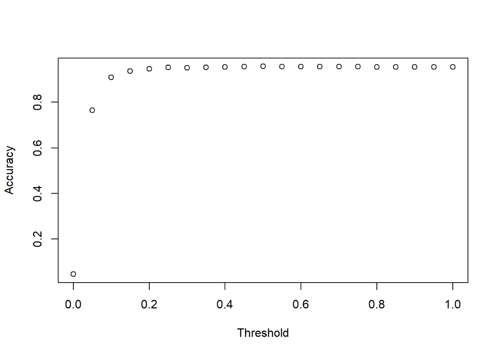

```r
thresh <- seq(0, 1, by = 0.05)
metric_acc <- rep(NA, length(thresh))
metric_ba <- rep(NA, length(thresh))

for (i in c(1:length(thresh))){

  y_hat_temp <- y_hat
  y_hat_temp[y_hat_temp > thresh[i]] <- 1
  y_hat_temp[y_hat_temp != 1] <- 0
  y_hat_temp <- factor(y_hat_temp, labels = c("1", "0"), levels = 1:0)

  metric_acc[i] <- confusionMatrix(y_hat_temp, reference = testing$y)$overall["Accuracy"]
  metric_ba[i] <- confusionMatrix(y_hat_temp, reference = testing$y)$byClass["Balanced Accuracy"]
}

plot(thresh, metric_acc, xlab = "Threshold", ylab = "Accuracy")
```

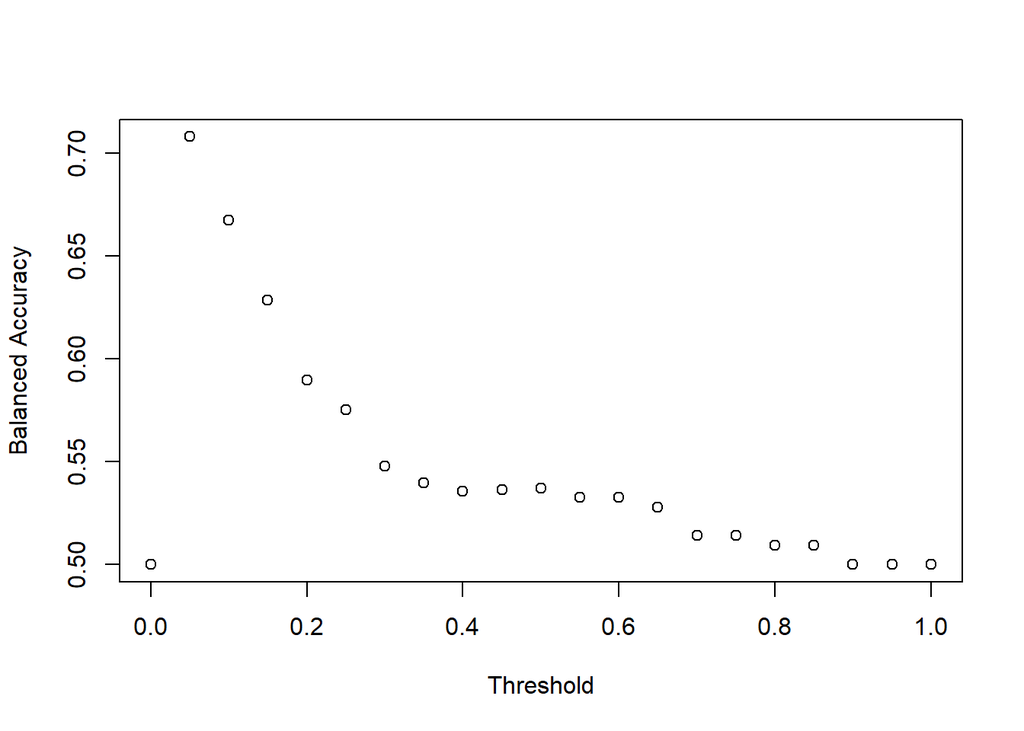

```r
plot(thresh, metric_ba, xlab = "Threshold", ylab = "Balanced Accuracy")
```

### Separating Datasets With Heuristics

Another way to deal with the imbalanced dataset could be to use heuristics to separate offensive messages from spam. In this case, we use the count of bad words to split the dataset between a “bad” dataframe (more likely to have offensive comments) and “good” dataframe (more likely to have spam). Then we fit the following models on both datasets separately:

- Logit
- Tree (single)
- KNN
- Elastic Net

#### Bad Dataset

We repeat the same operations as for the full dataset.

```r
# Setting Seed
set.seed(15)

# Divide Dataset
bad_df <- filter(reg_dataset, bad_word_count >= 1) #offensive messages
good_df <- filter(reg_dataset, bad_word_count < 1) #spam

# Pre-processing: removing variables with little variance
bad_trim_reg <- bad_df[ , !(names(bad_df) %in% nearZeroVar(bad_df, names = TRUE))]

### Optional: Remove ALL NAs
bad_trim_reg <- bad_trim_reg[complete.cases(bad_trim_reg), ]

# Re-adding Y
bad_trim_reg <- left_join(bad_trim_reg, select(reg_dataset, tag, y))
# Dividing Up Dataset
in_train <- sample(c(1:nrow(bad_trim_reg)), round(nrow(bad_trim_reg)*0.8, 0))
training <- bad_trim_reg[ in_train, ]
testing  <- bad_trim_reg[-in_train, ]

summary(training)
```

```
##    comment            video_id             likes
##  Length:5908        Length:5908        Min.   :   0.00
##  Class :character   Class :character   1st Qu.:   0.00
##  Mode  :character   Mode  :character   Median :   0.00
##                                        Mean   :  18.43
##                                        3rd Qu.:   0.00
##                                        Max.   :9854.00
##  video_title        video_channel_title video_category_id
##  Length:5908        Length:5908         Min.   : 1.00
##  Class :character   Class :character    1st Qu.:19.00
##  Mode  :character   Mode  :character    Median :24.00
##                                         Mean   :20.62
##                                         3rd Qu.:26.00
##                                         Max.   :28.00
##   video_tags         video_views        video_likes      video_dislikes
##  Length:5908        Min.   :    2874   Min.   :     45   Min.   :    0
##  Class :character   1st Qu.:  188162   1st Qu.:   4389   1st Qu.:  149
##  Mode  :character   Median :  466808   Median :  14870   Median :  452
##                     Mean   : 1176490   Mean   :  45732   Mean   : 2279
##                     3rd Qu.: 1307902   3rd Qu.:  34485   3rd Qu.: 1128
##                     Max.   :36323498   Max.   :1431683   Max.   :39774
##  video_comment_count clean_comment      comment_length     n_letters
##  Min.   :     7      Length:5908        Min.   :   3.0   Min.   :   3.0
##  1st Qu.:   597      Class :character   1st Qu.:  62.0   1st Qu.:  48.0
##  Median :  1696      Mode  :character   Median : 106.0   Median :  82.0
##  Mean   :  7171                         Mean   : 174.9   Mean   : 134.6
##  3rd Qu.:  5311                         3rd Qu.: 190.0   3rd Qu.: 146.0
##  Max.   :170708                         Max.   :9424.0   Max.   :7532.0
##  n_capital_letter  n_punctuation         n_digits         exclamation
##  Min.   :  0.000   Min.   :   0.000   Min.   :   0.000   Min.   : 0.0000
##  1st Qu.:  1.000   1st Qu.:   1.000   1st Qu.:   0.000   1st Qu.: 0.0000
##  Median :  3.000   Median :   3.000   Median :   0.000   Median : 0.0000
##  Mean   :  6.299   Mean   :   5.103   Mean   :   1.502   Mean   : 0.5322
##  3rd Qu.:  6.000   3rd Qu.:   6.000   3rd Qu.:   0.000   3rd Qu.: 0.0000
##  Max.   :943.000   Max.   :1003.000   Max.   :4004.000   Max.   :51.0000
##  video_category_id_pct video_views_pct     video_likes_pct
##  Min.   :0.00068       Min.   :      5.7   Min.   :    0.06
##  1st Qu.:0.08696       1st Qu.:   1396.2   1st Qu.:   36.02
##  Median :0.18246       Median :   4381.9   Median :  123.19
##  Mean   :0.26140       Mean   :  16124.3   Mean   :  601.25
```

[output cut: 57 more lines]

```
##  Max.   :38.0000   Max.   :42.0000   Max.   :1241.00   Max.   :75.000
##     sadness           surprise           trust         sentiment_both
##  Min.   : 0.0000   Min.   : 0.0000   Min.   : 0.0000   Min.   :-6205.000
##  1st Qu.: 0.0000   1st Qu.: 0.0000   1st Qu.: 0.0000   1st Qu.:   -3.000
##  Median : 0.0000   Median : 0.0000   Median : 0.0000   Median :    0.000
##  Mean   : 0.5958   Mean   : 0.3687   Mean   : 0.8409   Mean   :   -1.375
##  3rd Qu.: 1.0000   3rd Qu.: 1.0000   3rd Qu.: 1.0000   3rd Qu.:    2.000
##  Max.   :23.0000   Max.   :24.0000   Max.   :47.0000   Max.   :  129.074
##  sentiment_both_large y
##  Min.   :-6205.000    1: 361
##  1st Qu.:   -3.000    0:5547
##  Median :    0.000
##  Mean   :   -1.228
##  3rd Qu.:    2.000
##  Max.   :  633.370
```

```r
dim(training)
```

```
## [1] 5908   57
```

```r
# Finding Non-Numerical Columns
notnum <- sapply(training, is.numeric)[sapply(training, is.numeric) == FALSE]
notnum <- names(notnum)

# Removing them
poss_vars <- names(training)[!(names(training) %in% c(notnum, "y"))]
```

```r
## Logit Backward Selection
backward_selection(y = "y", current_preds = poss_vars, method = "logit")
```

```
## [1] "No variables left to remove."
```

```r
best_removed <- removed_var[1:which(best_metric == max(best_metric, na.rm = TRUE))]
new_vars <- poss_vars[!(poss_vars %in% best_removed)]

fmla <- as.formula(paste("y", " ~ ", paste(new_vars, collapse = "+"))) #adjusting formula
model <- train(fmla, data = training,   method = "glm", family = "binomial", trControl = ctrl)
confusionMatrix(predict(model, newdata = testing), reference = testing$y)
```

```
## Confusion Matrix and Statistics
##
##           Reference
## Prediction    1    0
##          1    8    8
##          0   77 1384
##
##                Accuracy : 0.9425
##                  95% CI : (0.9293, 0.9538)
##     No Information Rate : 0.9425
##     P-Value [Acc > NIR] : 0.5288
##
##                   Kappa : 0.1428
##
##  Mcnemar's Test P-Value : 1.636e-13
##
##             Sensitivity : 0.094118
##             Specificity : 0.994253
##          Pos Pred Value : 0.500000
##          Neg Pred Value : 0.947296
##              Prevalence : 0.057549
##          Detection Rate : 0.005416
##    Detection Prevalence : 0.010833
##       Balanced Accuracy : 0.544185
##
##        'Positive' Class : 1
##
```

The logit performs at the No Information Rate.

```r
fmla <- as.formula(paste("y", " ~ ", paste(poss_vars, collapse = "+"))) #adjusting formula
model <- train(fmla, data = training, method = "nnet", trControl = ctrl, tuneGrid = nnetGrid, preProcess = c("center", "scale"), trace = FALSE)
confusionMatrix(predict(model, newdata = testing), reference = testing$y)
```

```
## Confusion Matrix and Statistics
##
##           Reference
## Prediction    1    0
##          1    6   11
##          0   79 1381
##
##                Accuracy : 0.9391
##                  95% CI : (0.9256, 0.9507)
##     No Information Rate : 0.9425
##     P-Value [Acc > NIR] : 0.7339
##
##                   Kappa : 0.1004
##
##  Mcnemar's Test P-Value : 1.636e-12
##
##             Sensitivity : 0.070588
##             Specificity : 0.992098
##          Pos Pred Value : 0.352941
##          Neg Pred Value : 0.945890
##              Prevalence : 0.057549
##          Detection Rate : 0.004062
##    Detection Prevalence : 0.011510
##       Balanced Accuracy : 0.531343
##
##        'Positive' Class : 1
##
```

The neural net’s accuracy is now *below* the no information rate (i.e., is worse than classifying none of the comments as violations).

```r
fmla <- as.formula(paste("y", " ~ ", paste(poss_vars, collapse = "+"))) #adjusting formula
model <- train(fmla, data = training, method = "xgbTree", trControl = ctrl, tuneGrid = xgbGrid, metric = "Kappa")
confusionMatrix(predict(model, newdata = testing), reference = testing$y)
```

```
## Confusion Matrix and Statistics
##
##           Reference
## Prediction    1    0
##          1   15   13
##          0   70 1379
##
##                Accuracy : 0.9438
##                  95% CI : (0.9308, 0.955)
##     No Information Rate : 0.9425
##     P-Value [Acc > NIR] : 0.4398
##
##                   Kappa : 0.2439
##
##  Mcnemar's Test P-Value : 7.906e-10
##
##             Sensitivity : 0.17647
##             Specificity : 0.99066
##          Pos Pred Value : 0.53571
##          Neg Pred Value : 0.95169
##              Prevalence : 0.05755
##          Detection Rate : 0.01016
##    Detection Prevalence : 0.01896
##       Balanced Accuracy : 0.58357
##
##        'Positive' Class : 1
##
```

The XGB tree’s accuracy is extremely close to the no-prediction rate.

```r
## KNN Backward Selection
knnGrid <- data.frame(.k = 1:15)
backward_selection(y = "y", current_preds = poss_vars, method = "knn")
```

```
## [1] "No variables left to remove."
```

```r
best_removed <- removed_var[1:which(best_metric == max(best_metric, na.rm = TRUE))]
new_vars <- poss_vars[!(poss_vars %in% best_removed)]

fmla <- as.formula(paste("y", " ~ ", paste(new_vars, collapse = "+"))) #adjusting formula
model <- train(fmla, data = training, method = "knn", trControl = ctrl, tuneGrid = knnGrid)
confusionMatrix(predict(model, newdata = testing), reference = testing$y)
```

```
## Confusion Matrix and Statistics
##
##           Reference
## Prediction    1    0
##          1    2    0
##          0   83 1392
##
##                Accuracy : 0.9438
##                  95% CI : (0.9308, 0.955)
##     No Information Rate : 0.9425
##     P-Value [Acc > NIR] : 0.4398
##
##                   Kappa : 0.0434
##
##  Mcnemar's Test P-Value : <2e-16
##
##             Sensitivity : 0.023529
##             Specificity : 1.000000
##          Pos Pred Value : 1.000000
##          Neg Pred Value : 0.943729
##              Prevalence : 0.057549
##          Detection Rate : 0.001354
##    Detection Prevalence : 0.001354
##       Balanced Accuracy : 0.511765
##
##        'Positive' Class : 1
##
```

The KNN classifier also fails to improve on the no information rate.

#### Spam Dataset

Splitting the dataset did not seem to produce any results for most of the methods used above. We therefore just train the logit model onto the spam dataset.

```r
# Setting Seed
set.seed(15)

# Pre-processing: removing variables with little variance
good_trim_reg <- good_df[ , !(names(good_df) %in% nearZeroVar(good_df, names = TRUE))]

### Optional: Remove ALL NAs
good_trim_reg <- good_trim_reg[complete.cases(good_trim_reg), ]

# Re-adding Y
good_trim_reg <- left_join(good_trim_reg, select(reg_dataset, tag, y))
# Dividing Up Dataset
in_train <- sample(c(1:nrow(good_trim_reg)), round(nrow(good_trim_reg)*0.8, 0))
training <- good_trim_reg[ in_train, ]
testing  <- good_trim_reg[-in_train, ]

summary(training)
```

```
##    comment            video_id             likes
##  Length:3460        Length:3460        Min.   :   0.000
##  Class :character   Class :character   1st Qu.:   0.000
##  Mode  :character   Mode  :character   Median :   0.000
##                                        Mean   :   8.573
##                                        3rd Qu.:   0.000
##                                        Max.   :9438.000
##  video_title        video_channel_title video_category_id
##  Length:3460        Length:3460         Min.   : 1.00
##  Class :character   Class :character    1st Qu.:15.00
##  Mode  :character   Mode  :character    Median :23.00
##                                         Mean   :19.87
##                                         3rd Qu.:26.00
##                                         Max.   :28.00
##   video_tags         video_views        video_likes      video_dislikes
##  Length:3460        Min.   :    1002   Min.   :      8   Min.   :    0.0
##  Class :character   1st Qu.:  216040   1st Qu.:   4893   1st Qu.:  139.5
##  Mode  :character   Median :  470206   Median :  15424   Median :  458.0
##                     Mean   : 1302415   Mean   :  47160   Mean   : 1950.3
##                     3rd Qu.: 1275489   3rd Qu.:  38670   3rd Qu.: 1060.0
##                     Max.   :36323498   Max.   :1431683   Max.   :39774.0
##  video_comment_count clean_comment      comment_length     n_letters
##  Min.   :     3      Length:3460        Min.   :  3.00   Min.   :  3.00
##  1st Qu.:   582      Class :character   1st Qu.: 31.00   1st Qu.: 23.00
##  Median :  1914      Mode  :character   Median : 52.00   Median : 39.00
##  Mean   :  5578                         Mean   : 63.11   Mean   : 47.93
##  3rd Qu.:  4863                         3rd Qu.: 81.00   3rd Qu.: 61.00
##  Max.   :170708                         Max.   :673.00   Max.   :363.00
##  n_capital_letter  n_punctuation     exclamation
##  Min.   :  0.000   Min.   :  0.00   Min.   :  0.0000
##  1st Qu.:  1.000   1st Qu.:  0.00   1st Qu.:  0.0000
##  Median :  2.000   Median :  1.00   Median :  0.0000
##  Mean   :  6.612   Mean   :  2.31   Mean   :  0.6202
##  3rd Qu.:  4.000   3rd Qu.:  3.00   3rd Qu.:  0.0000
##  Max.   :342.000   Max.   :106.00   Max.   :105.0000
##  video_category_id_pct video_views_pct   video_likes_pct
##  Min.   :0.003401      Min.   :      7   Min.   :     0.17
##  1st Qu.:0.208333      1st Qu.:   3627   1st Qu.:    95.59
##  Median :0.373008      Median :   9830   Median :   316.05
##  Mean   :0.561288      Mean   :  38442   Mean   :  1369.79
```

[output cut: 36 more lines]

```
##  Max.   :4.0000   Max.   :6.0000   Max.   :8.0000   Max.   :7.0000
##     positive         sadness         surprise          trust
##  Min.   : 0.000   Min.   :0.000   Min.   :0.0000   Min.   : 0.0000
##  1st Qu.: 0.000   1st Qu.:0.000   1st Qu.:0.0000   1st Qu.: 0.0000
##  Median : 1.000   Median :0.000   Median :0.0000   Median : 0.0000
##  Mean   : 0.889   Mean   :0.239   Mean   :0.1566   Mean   : 0.4327
##  3rd Qu.: 1.000   3rd Qu.:0.000   3rd Qu.:0.0000   3rd Qu.: 1.0000
##  Max.   :17.000   Max.   :4.000   Max.   :6.0000   Max.   :10.0000
##  sentiment_both    sentiment_both_large y
##  Min.   :-23.000   Min.   :-23.0000     1:  88
##  1st Qu.:  0.000   1st Qu.:  0.0000     0:3372
##  Median :  0.000   Median :  0.0000
##  Mean   :  0.867   Mean   :  0.9764
##  3rd Qu.:  3.000   3rd Qu.:  3.0000
##  Max.   : 23.000   Max.   : 44.8500
```

```r
dim(training)
```

```
## [1] 3460   46
```

```r
# Finding Non-Numerical Columns
notnum <- sapply(training, is.numeric)[sapply(training, is.numeric) == FALSE]
notnum <- names(notnum)

# Removing them
poss_vars <- names(training)[!(names(training) %in% c(notnum, "y"))]

# Setting CV Parameter
ctrl <- trainControl(method = "cv", number = 10)
```

```r
## Logit Backward Selection
backward_selection(y = "y", current_preds = poss_vars, method = "logit")
```

```
## [1] "No variables left to remove."
```

```r
best_removed <- removed_var[1:which(best_metric == max(best_metric, na.rm = TRUE))]
new_vars <- poss_vars[!(poss_vars %in% best_removed)]

fmla <- as.formula(paste("y", " ~ ", paste(new_vars, collapse = "+"))) #adjusting formula
model <- train(fmla, data = training,   method = "glm", family = "binomial", trControl = ctrl)
confusionMatrix(predict(model, newdata = testing), reference = testing$y)
```

```
## Confusion Matrix and Statistics
##
##           Reference
## Prediction   1   0
##          1   0   0
##          0  21 844
##
##                Accuracy : 0.9757
##                  95% CI : (0.9631, 0.9849)
##     No Information Rate : 0.9757
##     P-Value [Acc > NIR] : 0.5577
##
##                   Kappa : 0
##
##  Mcnemar's Test P-Value : 1.275e-05
##
##             Sensitivity : 0.00000
##             Specificity : 1.00000
##          Pos Pred Value :     NaN
##          Neg Pred Value : 0.97572
##              Prevalence : 0.02428
##          Detection Rate : 0.00000
##    Detection Prevalence : 0.00000
##       Balanced Accuracy : 0.50000
##
##        'Positive' Class : 1
##
```

The logit model’s performance when trained on the spam dataset is *worse* than its performance on the full dataset. There is therefore no incentive to split the dataset in this way.

## Conclusion

The best performing model is the logit, with an accuracy of +- 96% (Kappa of 0.3) when including “bad word” columns. The model’s performance, when compared to the No Information Rate, is fairly low.

Changes such as splitting the dataframe based on heuristics, using up/downsampling and different metrics failed to produce any results. Ultimately, the logit was the best model for our data, as it ran quickly and could use important, low-variance variables.

Our model could have been improved by labelling our observations, to better differentiate between the different types of community violations. It would also have been helpful to incorporate more context-related variables into the dataset, such as content tags, user history, etc. More refined variables, which take into account the target of a message, would also have been helpful. Finally, having more data, to cope with our limited number of observations, would also have improved our model’s performance.

Ultimately, this was a fairly difficult task, as context makes it hard to distinguish between truly offensive and merely mean messages.

## Works Cited

- Boyle, Tara. “Dealing with Imbalanced Data.” Medium. 2019.
- Elsinghorst, Shirin. “Dealing with Unbalanced Data in Machine Learning.” Sitewide ATOM, Github, 2 Apr. 2017, shiring.github.io/machine_learning/2017/04/02/unbalanced.
- Hatebase. “Academia.” Hatebase, Hatebase Inc., 2019, hatebase.org/academia.
- Nguyen, Thu T., et al. “Pride, Love, and Twitter Rants: Combining Machine Learning and Qualitative Techniques to Understand What our Tweets Reveal About Race in the US.” International Journal of Environmental Research and Public Health 16.10 (2019): 1766.
- Papegnies, Etienne, et al. “Impact of Content Features for Automatic Online Abuse Detection.” International Conference on Computational Linguistics and Intelligent Text Processing. Springer, Cham, 2017.
- Rocca, Baptiste. “Handling Imbalanced Datasets in Machine Learning.” Medium, Towards Data Science, 30 Mar. 2019, towardsdatascience.com/handling-imbalanced-datasets-in-machine-learning-7a0e84220f28.
- Schmidt, Anna, and Michael Wiegand. “A survey on Hate Speech Detection Using Natural Language Processing.” Proceedings of the Fifth International Workshop on Natural Language Processing for Social Media. 2017.